# 추론통계_경희대

### 4.3 상관계수의 시각화 2

[figure not shown]

```r
#install.packages("corrgram")
library(corrgram)
corrgram(x)
```

[figure not shown]

```r
corrgram(iris, upper.panel=panel.conf) # 대응되는 패널을 상관계수(신뢰구간)로 바꾸어 보여준다.
```

### 4.4 스피어만 상관 계수. cor(matrix, method=“spearman”)

- 실제값 대신 두 값의 _순위_를 사용해 상관계수를 구하는 방식.

```r
kor <- c(85,90,87,92,95)
eng <- c(88,89,68,84,91)
m<- matrix(c(kor,eng), ncol=2)
cor(m, method="spearman")
```

```
##      [,1] [,2]
## [1,]  1.0  0.5
## [2,]  0.5  1.0
```

### 4.5 상관 계수 검정

- 상관계수의 통계적 유의성을 살펴본다.
- 귀무가설은 상관계수가 0이다.

```r
x1 <- c(1,2,3,4,5)
x2 <- c(1,0,3,4,5)
cor.test(x1,x2,method = "pearson") # 귀무가설을 기각한다.
```

```
##
##  Pearson's product-moment correlation
##
## data:  x1 and x2
## t = 3.9279, df = 3, p-value = 0.02937
## alternative hypothesis: true correlation is not equal to 0
## 95 percent confidence interval:
##  0.1697938 0.9944622
## sample estimates:
##       cor
## 0.9149914
```

```r
cor.test(x1,x2,method = "spearman") # 귀무가설을 채택한다.
```

```
##
##  Spearman's rank correlation rho
##
## data:  x1 and x2
## S = 2, p-value = 0.08333
## alternative hypothesis: true rho is not equal to 0
## sample estimates:
## rho
## 0.9
```

### example

#### 연습1

```r
#1. Pclass와 Fare의 피어슨 상과 계수의 값은 얼마인가?
Data$Pclass<-as.numeric(Data$Pclass)
cor(Data$Pclass,Data$Fare)
```

```
## [1] -0.5494996
```

```r
#2. Pclass와 Fare의 상관 계수가 음수를 갖는다면 그 의미는 무엇인가?
# 서로 반대 방향. 반비례 관계
```

#### 연습2

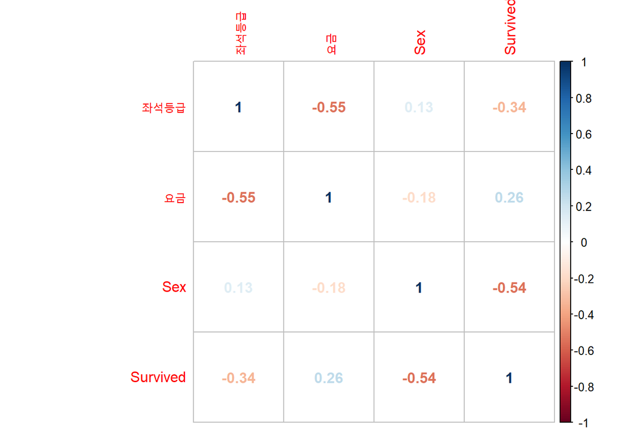

```r
for_corr<-data.frame(Data$Pclass, Data$Fare)
colnames(for_corr) <- c("좌석등급","요금")
for_corr$Sex <- as.integer(Data$Sex)
for_corr$Survived <- as.integer(Data$Survived)
library(corrplot)
corr <- cor(for_corr)
corrplot(corr, method="number")
```

#### 연습3

```r
#corrgram 라이브러리를 활용하여, 이전 문제에서 구한 상관계수를 시각화하시오.
#1. Survived 와 연관성이 높은 순서별로 나열.
cor(for_corr) # Sex > 좌석등급 > 요금
```

```
##            좌석등급       요금        Sex   Survived
## 좌석등급  1.0000000 -0.5494996  0.1319005 -0.3384810
## 요금     -0.5494996  1.0000000 -0.1823328  0.2573065
## Sex       0.1319005 -0.1823328  1.0000000 -0.5433514
## Survived -0.3384810  0.2573065 -0.5433514  1.0000000
```

[figure not shown]

```r
corrgram(cor(for_corr))
```

```r
#2. 생존자를 예측할 때 한 변수만을 선택한다면 당신의 선택은 ?
# Sex;

cor(for_corr, method="spearman")# spearman 상관계수 활용.
```

```
##            좌석등급       요금        Sex   Survived
## 좌석등급  1.0000000 -0.6880317  0.1357745 -0.3396679
## 요금     -0.6880317  1.0000000 -0.2595935  0.3237361
## Sex       0.1357745 -0.2595935  1.0000000 -0.5433514
## Survived -0.3396679  0.3237361 -0.5433514  1.0000000
```

## 5. 집단 차이 분석

### 5.1 일표본 평균

- 하나의 모집단으로부터 표본을 추출하여 평균 신뢰구간 구하기

```r
alternative <- c('two.sided','less','greater')
mu=0
x<-rnorm(30)
t.test(x,mu=mu,alternative = alternative[2]) # 모집단의 평균이 mu 이냐 ? 그렇다.
```

```
##
##  One Sample t-test
##
## data:  x
## t = -1.6459, df = 29, p-value = 0.05529
## alternative hypothesis: true mean is less than 0
## 95 percent confidence interval:
##         -Inf 0.009225656
## sample estimates:
##  mean of x
## -0.2855265
```

```r
# twe.sided 는 다르다. less, greater는 하한,상한 단측 검정
```

### 5.2 독립 이표본 평균

- 두 모집단에서 독립적인 표본을 추출하여 두 모집단의 평균이 같은지를 살펴본다.
- 예) A, B 학교 학생의 키평균이 같은지를 검사.
  - 1. 데이터 확인: 서로 상관이 없는 두 그룹의 데이터인지 확인
  - 2. 모분산이 같은지 확인. *var.test(var~group, data)* 사용

#### 5.2.1 데이터 확인

```r
head(sleep)
```

```
##   extra group ID
## 1   0.7     1  1
## 2  -1.6     1  2
## 3  -0.2     1  3
## 4  -1.2     1  4
## 5  -0.1     1  5
## 6   3.4     1  6
```

```r
tail(sleep)
```

```
##    extra group ID
## 15  -0.1     2  5
## 16   4.4     2  6
## 17   5.5     2  7
## 18   1.6     2  8
## 19   4.6     2  9
## 20   3.4     2 10
```

```r
sleep2 <- sleep[,c(1,2)] # 필요없는 환자 ID 변수를 버린다. 이 데이터 원래의 목적과 다르기 때문에 불필요하다고 판단.
```

#### 5.2.2 모분산이 같은지 확인

```r
var.test(extra ~group, sleep2)
```

```
##
##  F test to compare two variances
##
## data:  extra by group
## F = 0.79834, num df = 9, denom df = 9, p-value = 0.7427
## alternative hypothesis: true ratio of variances is not equal to 1
## 95 percent confidence interval:
##  0.198297 3.214123
## sample estimates:
## ratio of variances
##          0.7983426
```

```r
# 귀무가설은 '분산의 비가 1이다' 이며 p 값을 보아하니 귀무가설을 채택해야한다.
```

#### 5.2.3 t.test()

```r
t.test(extra~ group, data=sleep2, pairs=FALSE, var.equal=TRUE) # 귀무가설을 채택 ! 신뢰구간에 0이 포함되네?
```

```
##
##  Two Sample t-test
##
## data:  extra by group
## t = -1.8608, df = 18, p-value = 0.07919
## alternative hypothesis: true difference in means is not equal to 0
## 95 percent confidence interval:
##  -3.363874  0.203874
## sample estimates:
## mean in group 1 mean in group 2
##            0.75            2.33
```

### 5.3 짝지은 이표본 평균

- 두 모집단에서 연관된 표본을 추출하여 두 모집단의 평균이 같은지를 살펴본다.
- 동일한 대상에 대하여 어떠한 변수가 영향을 미쳤는지를 검사

#### 5.3.1 데이터 확인

```r
# sleep 데이터 그대로 활용
```

#### 5.3.2 t.test()

```r
t.test(sleep$extra[sleep$group==1], sleep$extra[sleep$group==2],paired=T) #paired에 의해서 짝지어져 같은 사람으로 인지
```

```
##
##  Paired t-test
##
## data:  sleep$extra[sleep$group == 1] and sleep$extra[sleep$group == 2]
## t = -4.0621, df = 9, p-value = 0.002833
## alternative hypothesis: true difference in means is not equal to 0
## 95 percent confidence interval:
##  -2.4598858 -0.7001142
## sample estimates:
## mean of the differences
##                   -1.58
```

### 5.4 일표본 비율1

- 모집단의 비율 추정
- 예) 찬반 비율 중 어느 것이 더 큰지 추정할 때
- 정규분포 사ㅇ

```r
prop.test(42,100) # default = 0.5
```

```
##
##  1-sample proportions test with continuity correction
##
## data:  42 out of 100, null probability 0.5
## X-squared = 2.25, df = 1, p-value = 0.1336
## alternative hypothesis: true p is not equal to 0.5
## 95 percent confidence interval:
##  0.3233236 0.5228954
## sample estimates:
##    p
## 0.42
```

```r
prop.test(42,100,0.5)
```

```
##
##  1-sample proportions test with continuity correction
##
## data:  42 out of 100, null probability 0.5
## X-squared = 2.25, df = 1, p-value = 0.1336
## alternative hypothesis: true p is not equal to 0.5
## 95 percent confidence interval:
##  0.3233236 0.5228954
## sample estimates:
##    p
## 0.42
```

```r
# p 값이 0.13. 귀무가설을 채택. 즉, "찬성 비율이 0.5 이다" . 그렇다.
```

### 5.5 일표본 비율 2

- 모집단 비율 추정
- 정규분포를 사용하지 않고, 신뢰구간을 직접계산

```r
binom.test(42,100)
```

```
##
##  Exact binomial test
##
## data:  42 and 100
## number of successes = 42, number of trials = 100, p-value = 0.1332
## alternative hypothesis: true probability of success is not equal to 0.5
## 95 percent confidence interval:
##  0.3219855 0.5228808
## sample estimates:
## probability of success
##                   0.42
```

```r
binom.test(42,100,0.5)
```

```
##
##  Exact binomial test
##
## data:  42 and 100
## number of successes = 42, number of trials = 100, p-value = 0.1332
## alternative hypothesis: true probability of success is not equal to 0.5
## 95 percent confidence interval:
##  0.3219855 0.5228808
## sample estimates:
## probability of success
##                   0.42
```

### 5.6 이표본 비율

- 두 표본으로 부터 모집단의 비율을 추정, 가설검정.
- 예) 남녀 흡연율에 차이가 있는지 비교.

```r
prop.test(c(45,55), c(100,90))  # 남성45, 여성55 흡연자.  남성100, 여성90 모집단.
```

```
##
##  2-sample test for equality of proportions with continuity
##  correction
##
## data:  c(45, 55) out of c(100, 90)
## X-squared = 4.3067, df = 1, p-value = 0.03796
## alternative hypothesis: two.sided
## 95 percent confidence interval:
##  -0.31185005 -0.01037217
## sample estimates:
##    prop 1    prop 2
## 0.4500000 0.6111111
```

```r
# 결과: 두 집단의 흡연율은 차이가 있다 ~
```

지긋지긋한 경고메세지 Warning message: In strsplit(code, “”, fixed = TRUE) : input string 1 is invalid in this locale

재부팅 후 다음 명령어 실행 > Sys.getlocale() > Sys.setlocale(‘LC_ALL’,‘C’)